# Análisis exploratorio de datos2

## 1. Obtener los datos

### 1.1. Datos sobre educación:

Vamos a obtener los datos sobre acreditación por departamentos, años y nivel de educación teniendo en cuenta, a falta de la definición de una variable proxy en el [documento](http://www.mineducacion.gov.co/1759/w3-article-329021.html) del MEN, la acreditación en los diferentes niveles educativos nos da cuenta tanto de la diversidad de la propuesta educativa como de su calidad.

Dado que provienen de distintas tablas, es necesario verificar que los años coincidan, los departamentos y su escritura y los niveles educativos:

```r
setwd("~/Documents/datathonlatam") ## setting dir
library(readr)
arc <- list.files("./datasets/educacion_superior", pattern = ".csv") ## creating list files csv

acreditacion <- read_csv(paste("./datasets/educacion_superior", arc[1], sep = "/"))
names(acreditacion) <- c("departamento", "anio",
                         paste("acr", gsub("tecnica profesional", "tecpro", tolower(names(acreditacion)[3:8])), sep = "_") )
```

Una ves juntamos todos los datos, vamos a verificar que estén todos los departamentos, de cuáles años hay registros y los niveles educativos presentes:

```r
departamentos <- sort(unique(acreditacion$departamento))
print("Tenemos los siguientes departamentos:")
```

```
## [1] "Tenemos los siguientes departamentos:"
```

```r
departamentos
```

```
##  [1] "AMAZONAS"                 "ANTIOQUIA"
##  [3] "ARAUCA"                   "ATLANTICO"
##  [5] "BOGOTA D.C."              "BOLIVAR"
##  [7] "BOYACA"                   "CALDAS"
##  [9] "CAQUETA"                  "CASANARE"
## [11] "CAUCA"                    "CESAR"
## [13] "CHOCO"                    "CORDOBA"
## [15] "CUNDINAMARCA"             "GUAINIA"
## [17] "GUAVIARE"                 "HUILA"
## [19] "LA GUAJIRA"               "MAGDALENA"
## [21] "META"                     "NARINO"
## [23] "NORTE DE SANTANDER"       "PUTUMAYO"
## [25] "QUINDIO"                  "RISARALDA"
## [27] "SAN ANDRES Y PROVIDENCIA" "SANTANDER"
## [29] "SUCRE"                    "TOLIMA"
## [31] "VALLE DEL CAUCA"          "VAUPES"
## [33] "VICHADA"
```

```r
print("Para los años:")
```

```
## [1] "Para los años:"
```

```r
sort(unique(acreditacion$anio))
```

```
## [1] 2010 2011 2012 2013 2014 2015
```

```r
print("Y para los niveles educativos:")
```

```
## [1] "Y para los niveles educativos:"
```

```r
colnames(acreditacion[3:8])
```

```
## [1] "acr_tecpro"          "acr_tecnologica"     "acr_universitaria"
## [4] "acr_especializacion" "acr_maestria"        "acr_doctorado"
```

```r
saveRDS(departamentos, "./departamentosRDS")
```

### 1.2. Obtener los datos sobre PIB:

```r
totalpib <- data.frame() ## empty data frame to fill
k <- 0 ## a counter for naming by department from departamentos var
departamentos <- readRDS("./departamentosRDS")
library(readxl) ## library needed to read xls
for(i in seq(from = 2, to = 66, by = 2)) { ## We'll read even sheets (by number, not by name)

pib <- read_excel("~/Documents/datathonlatam/datasets/Copia de PIB_Departamentos_2015provisional.xls",
                 sheet = i, skip = 5, range = "A7:Q59") ## read just a range of the sheet
pib <- pib[!is.na(pib[, 1]) & !is.na(pib[, 2]), c(1, 2:16)] ## delete NAs and keep 2010 to 2015
pib <- data.frame(t(pib)) ## transpose
k <- k + 1 ## increase 'iterator' of departamentos names
pib$departamento <- departamentos[k] ## namig the departamento
pib$anio <- rownames(pib) ## anio as value not just as rowname
pib <- pib[c(2:nrow(pib)), c(48:49, 1:47)] ## erasing first row and reordering cols-vars
totalpib <- rbind(totalpib, pib) ## stacking results in one data frame
}

rm(pib) ## erase inecessary data frame

totalpib[, 3:ncol(totalpib)] <- apply(totalpib[, 3:ncol(totalpib)], 2, as.integer) ## data as numeric

print("los departamentos que quedan son:")
```

```
## [1] "los departamentos que quedan son:"
```

```r
sort(unique(totalpib$departamento))
```

```
##  [1] "AMAZONAS"                 "ANTIOQUIA"
##  [3] "ARAUCA"                   "ATLANTICO"
##  [5] "BOGOTA D.C."              "BOLIVAR"
##  [7] "BOYACA"                   "CALDAS"
##  [9] "CAQUETA"                  "CASANARE"
## [11] "CAUCA"                    "CESAR"
## [13] "CHOCO"                    "CORDOBA"
## [15] "CUNDINAMARCA"             "GUAINIA"
## [17] "GUAVIARE"                 "HUILA"
## [19] "LA GUAJIRA"               "MAGDALENA"
## [21] "META"                     "NARINO"
## [23] "NORTE DE SANTANDER"       "PUTUMAYO"
## [25] "QUINDIO"                  "RISARALDA"
## [27] "SAN ANDRES Y PROVIDENCIA" "SANTANDER"
## [29] "SUCRE"                    "TOLIMA"
## [31] "VALLE DEL CAUCA"          "VAUPES"
## [33] "VICHADA"
```

```r
print("Y los años:")
```

```
## [1] "Y los años:"
```

```r
sort(unique(totalpib$anio))
```

```
##  [1] "2000" "2001" "2002" "2003" "2004" "2005" "2006" "2007" "2008" "2009"
## [11] "2010" "2011" "2012" "2013" "2014"
```

```r
library(readr)
dummy_names_PIB <- as.data.frame(read_csv("~/Documents/datathonlatam/dummy_names_PIB.csv")[, c(1:2)])
print("Dado que no podemos conservar el nombre completo-descriptivo de cada variable, dejamos una tabla en el que se relacionan las convenciones y el nombre original")
```

```
## [1] "Dado que no podemos conservar el nombre completo-descriptivo de cada variable, dejamos una tabla en el que se relacionan las convenciones y el nombre original"
```

```r
dummy_names_PIB
```

```
##    nombre_corto
## 1            X1
## 2            X2
## 3            X3
## 4            X4
## 5            X5
## 6            X6
## 7            X7
## 8            X8
## 9            X9
## 10          X10
## 11          X11
## 12          X12
## 13          X13
## 14          X14
```

[output cut: 81 more lines]

### 1.3. Obtener los datos sobre proyecciones poblacionales del DANE según censo 2005:

```r
library(readr)
dane <- read_csv("./datasets/censo 2005/proyeccion poblacion DANE 2005.csv")

totaldane <- data.frame()
for( i in 1:nrow(dane)){
    temp <- data.frame(departamento = dane[i, 1],
                                  anio = seq(1985, 2020),
                                  proy = as.numeric(dane[i, 2:ncol(dane)]))
    totaldane <- rbind(totaldane, temp)
}

rm(list = c("dane", "temp"))

print("los departamentos que quedan son:")
```

```
## [1] "los departamentos que quedan son:"
```

```r
sort(unique(totaldane$departamento))
```

```
##  [1] "AMAZONAS"                 "ANTIOQUIA"
##  [3] "ARAUCA"                   "ATLANTICO"
##  [5] "BOGOTA D.C."              "BOLIVAR"
##  [7] "BOYACA"                   "CALDAS"
##  [9] "CAQUETA"                  "CASANARE"
## [11] "CAUCA"                    "CESAR"
## [13] "CHOCO"                    "CORDOBA"
## [15] "CUNDINAMARCA"             "GUAINIA"
## [17] "GUAVIARE"                 "HUILA"
## [19] "LA GUAJIRA"               "MAGDALENA"
## [21] "META"                     "NARINO"
## [23] "NORTE DE SANTANDER"       "PUTUMAYO"
## [25] "QUINDIO"                  "RISARALDA"
## [27] "SAN ANDRES Y PROVIDENCIA" "SANTANDER"
## [29] "SUCRE"                    "TOLIMA"
## [31] "VALLE DEL CAUCA"          "VAUPES"
## [33] "VICHADA"
```

```r
print("Y los años:")
```

```
## [1] "Y los años:"
```

```r
sort(unique(totaldane$anio))
```

```
##  [1] 1985 1986 1987 1988 1989 1990 1991 1992 1993 1994 1995 1996 1997 1998
## [15] 1999 2000 2001 2002 2003 2004 2005 2006 2007 2008 2009 2010 2011 2012
## [29] 2013 2014 2015 2016 2017 2018 2019 2020
```

### 1.4. Juntar todos los datos:

```
## 'data.frame':    165 obs. of  56 variables:
##  $ departamento       : Factor w/ 33 levels "AMAZONAS","ANTIOQUIA",..: 1 1 1 1 1 2 2 2 2 2 ...
##  $ anio               : int  2010 2011 2012 2013 2014 2010 2011 2012 2013 2014 ...
##  $ proy               : int  45509584 46044601 46581823 47121089 47661787 4383277 4428675 4474369 4520480 4566875 ...
##  $ X1                 : int  53 50 51 52 61 4495 4859 4874 5206 5420 ...
##  $ X2                 : int  0 0 0 0 0 645 754 562 690 761 ...
##  $ X3                 : int  0 1 0 0 0 2201 2354 2471 2592 2520 ...
##  $ X4                 : int  2 2 2 2 2 1544 1627 1702 1766 1924 ...
##  $ X5                 : int  7 7 8 10 9 89 103 114 132 183 ...
##  $ X6                 : int  44 40 41 40 50 16 21 25 26 32 ...
##  $ X7                 : int  0 0 0 0 0 1718 2434 2985 2853 2645 ...
##  $ X8                 : int  0 0 0 0 0 17 43 19 11 25 ...
##  $ X9                 : int  0 0 0 0 0 749 1155 1432 1553 1232 ...
##  $ X10                : int  0 0 0 0 0 697 931 1218 928 927 ...
##  $ X11                : int  0 0 0 0 0 255 305 316 361 461 ...
```

[output cut: 42 more lines]

## 2. Análisis exploratorio de datos:

### 2.1. Eliminando variables PIB redundantes:

Ahora que tenemos todos los datos juntos, lo primero que necesitamos es remover algunas variables del PIB que son suma de otras (X1 es la suma de X2 a X6, X7 es la suma de X8 a X11 … Las que aparecen relacionadas en mayúscula son la suma de las isguientes en minúsculas, de acuerdo con la tabla presentada en el apartado 1.2. Obtener los datos sobre PIB:) ya que son redundantes.

### 2.2. Revisando correlaciones:

Una vez retiradas podemos revisar las correlaciones entre todas las variables del PIB y las de acreditación en educación superior por nivel educativo; dejando por fuera los datos no numéricos: los nombres de los departamentos.

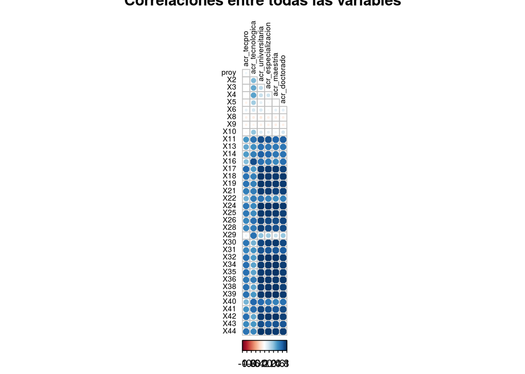

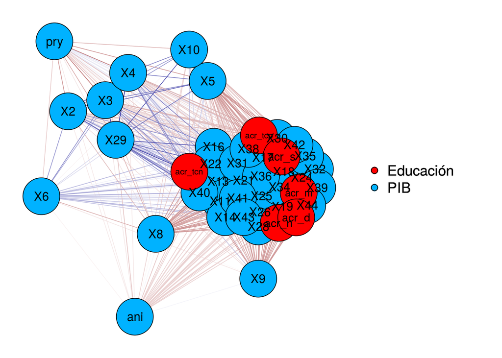

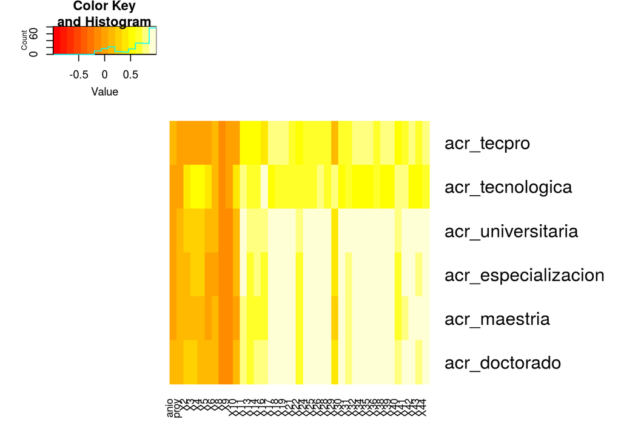

```
##                           anio       proy          X2         X3
## acr_tecpro          0.07346082 0.06096417 -0.01733912 0.01028764
## acr_tecnologica     0.03700365 0.03713761  0.44285604 0.51650966
## acr_universitaria   0.05861559 0.06688848  0.21755476 0.25522807
## acr_especializacion 0.04473665 0.08336999  0.12064726 0.20086757
## acr_maestria        0.05887539 0.08347146  0.09835823 0.11983877
## acr_doctorado       0.07258512 0.08665516  0.21813665 0.21512213
##                               X4          X5         X6          X8
## acr_tecpro          -0.001889363 -0.06097334 0.09881419 -0.07401902
## acr_tecnologica      0.539585028  0.34002719 0.17862916 -0.09537389
## acr_universitaria    0.228255207  0.10794927 0.14535051 -0.10606516
## acr_especializacion  0.203242388  0.03692331 0.03797430 -0.08593527
## acr_maestria         0.097706373  0.01373373 0.10517754 -0.08537518
## acr_doctorado        0.197647858  0.12459479 0.11464843 -0.08592765
##                              X9         X10       X11       X13       X14
## acr_tecpro          -0.06238422 -0.03994782 0.5839307 0.5146880 0.5689773
## acr_tecnologica     -0.05824440  0.39183401 0.7423403 0.6166575 0.6832924
## acr_universitaria   -0.07598184  0.14963737 0.8879268 0.7525944 0.8149712
## acr_especializacion -0.07566704  0.11122366 0.8653752 0.7230019 0.7825220
## acr_maestria        -0.08293805  0.05782900 0.7997899 0.7180260 0.7269328
## acr_doctorado       -0.07671714  0.18305480 0.8298424 0.7223131 0.7333010
##                           X16       X17       X18       X19       X21
## acr_tecpro          0.4211869 0.7713430 0.7302088 0.7322636 0.6873769
## acr_tecnologica     0.8828883 0.5722778 0.6838506 0.6769843 0.6992654
## acr_universitaria   0.7588508 0.9568053 0.9791681 0.9777987 0.9583047
## acr_especializacion 0.7172540 0.9585457 0.9663521 0.9666263 0.9575978
## acr_maestria        0.6443916 0.9641490 0.9641364 0.9644577 0.9279725
## acr_doctorado       0.7574592 0.9254482 0.9615770 0.9583221 0.9309905
##                           X22       X24       X25       X26       X28
## acr_tecpro          0.4709339 0.7268049 0.7191197 0.6455846 0.6518248
## acr_tecnologica     0.7086367 0.6458546 0.6352381 0.7514465 0.7088317
## acr_universitaria   0.7418878 0.9808497 0.9610216 0.9365753 0.9375583
## acr_especializacion 0.6852860 0.9892780 0.9683235 0.9088240 0.9080794
## acr_maestria        0.6198805 0.9827838 0.9649410 0.8908697 0.8871980
## acr_doctorado       0.6866480 0.9670852 0.9380159 0.9185339 0.8939005
##                            X29       X30       X31       X32       X34
## acr_tecpro          0.07475124 0.7225057 0.6547477 0.7439150 0.7521866
## acr_tecnologica     0.74362631 0.4792212 0.6072180 0.5782948 0.5347228
## acr_universitaria   0.40727875 0.9159427 0.8607277 0.9674019 0.9550068
## acr_especializacion 0.36254939 0.9454556 0.8525570 0.9812148 0.9741064
## acr_maestria        0.23389280 0.9664722 0.8523674 0.9837008 0.9890681
## acr_doctorado       0.38581399 0.9069541 0.8265073 0.9433796 0.9465143
##                           X35       X36       X38       X39       X40
## acr_tecpro          0.7556965 0.7065277 0.7422986 0.7400456 0.4693818
## acr_tecnologica     0.5374682 0.6997011 0.5378336 0.5801125 0.7800640
## acr_universitaria   0.9598720 0.9782299 0.9505675 0.9690442 0.7774009
## acr_especializacion 0.9646179 0.9627333 0.9700495 0.9847556 0.7209350
## acr_maestria        0.9869341 0.9626976 0.9802660 0.9913365 0.6701953
## acr_doctorado       0.9415588 0.9653648 0.9313916 0.9595194 0.7481473
##                           X41       X42       X43       X44
## acr_tecpro          0.6005697 0.7561000 0.6404676 0.7316552
## acr_tecnologica     0.7699199 0.5246032 0.5855231 0.6501187
## acr_universitaria   0.9108276 0.9524413 0.8840326 0.9711210
## acr_especializacion 0.8711185 0.9721451 0.8283960 0.9615659
## acr_maestria        0.8489680 0.9856200 0.8650814 0.9595195
## acr_doctorado       0.8936394 0.9343866 0.8530790 0.9429277
```

```r
acr_tecpro <- df_limpio[, c(1:39)]
model <- lm(acr_tecpro ~ ., data = acr_tecpro)
summary(model)
```

```
##
## Call:
## lm(formula = acr_tecpro ~ ., data = acr_tecpro)
##
## Residuals:
##     Min      1Q  Median      3Q     Max
## -394.41  -67.76    0.99   80.64  605.34
##
## Coefficients:
##                                        Estimate Std. Error t value
## (Intercept)                          -6.048e+03  4.585e+04  -0.132
## departamentoANTIOQUIA                 7.352e+03  6.464e+03   1.137
## departamentoARAUCA                    1.076e+03  5.344e+03   0.201
## departamentoATLANTICO                -5.748e+02  5.343e+03  -0.108
## departamentoBOGOTA D.C.               2.794e+04  7.678e+03   3.639
## departamentoBOLIVAR                  -4.671e+02  5.196e+03  -0.090
## departamentoBOYACA                    1.437e+03  5.378e+03   0.267
## departamentoCALDAS                    2.604e+03  5.251e+03   0.496
## departamentoCAQUETA                   1.161e+03  5.315e+03   0.218
## departamentoCASANARE                  8.717e+02  5.339e+03   0.163
## departamentoCAUCA                     4.681e+03  5.221e+03   0.897
## departamentoCESAR                     7.611e+02  5.262e+03   0.145
## departamentoCHOCO                     3.021e+03  5.373e+03   0.562
## departamentoCORDOBA                   2.052e+03  5.195e+03   0.395
## departamentoCUNDINAMARCA              6.084e+03  5.501e+03   1.106
## departamentoGUAINIA                   7.408e+02  5.272e+03   0.141
## departamentoGUAVIARE                  6.684e+02  5.392e+03   0.124
## departamentoHUILA                     1.288e+03  5.292e+03   0.243
## departamentoLA GUAJIRA                7.819e+02  5.261e+03   0.149
## departamentoMAGDALENA                 1.246e+03  5.212e+03   0.239
## departamentoMETA                      1.872e+03  5.243e+03   0.357
## departamentoNARINO                    1.305e+03  5.167e+03   0.253
## departamentoNORTE DE SANTANDER        4.136e+03  5.196e+03   0.796
## departamentoPUTUMAYO                  1.416e+03  5.351e+03   0.265
## departamentoQUINDIO                   4.658e+02  5.304e+03   0.088
## departamentoRISARALDA                 2.699e+03  5.248e+03   0.514
## departamentoSAN ANDRES Y PROVIDENCIA  5.210e+02  5.381e+03   0.097
## departamentoSANTANDER                 1.944e+02  5.280e+03   0.037
## departamentoSUCRE                     3.122e+02  5.269e+03   0.059
## departamentoTOLIMA                    2.536e+03  5.039e+03   0.503
```

[output cut: 102 more lines]

```
## X35                                  0.332057
## X36                                  6.71e-07 ***
## X38                                  0.005795 **
## X39                                  1.21e-09 ***
## X40                                  9.34e-06 ***
## X41                                  0.133305
## X42                                  5.69e-05 ***
## X43                                  0.806497
## X44                                  0.001259 **
## ---
## Signif. codes:  0 '***' 0.001 '**' 0.01 '*' 0.05 '.' 0.1 ' ' 1
##
## Residual standard error: 183.1 on 95 degrees of freedom
## Multiple R-squared:  0.9804, Adjusted R-squared:  0.9661
## F-statistic: 68.73 on 69 and 95 DF,  p-value: < 2.2e-16
```

```r
acr_tecpro <- df_limpio[, c(2:39)]
model <- lm(acr_tecpro ~ ., data = acr_tecpro)
summary(model)
```

```
##
## Call:
## lm(formula = acr_tecpro ~ ., data = acr_tecpro)
##
## Residuals:
##      Min       1Q   Median       3Q      Max
## -1244.90  -187.45    -7.61   192.69  1576.83
##
## Coefficients:
##               Estimate Std. Error t value Pr(>|t|)
## (Intercept)  3.326e+04  6.310e+04   0.527 0.599036
## anio        -1.660e+01  3.138e+01  -0.529 0.597767
## proy         1.038e-05  6.364e-06   1.630 0.105490
## X2          -2.080e+00  6.404e-01  -3.247 0.001490 **
## X3           9.872e-01  4.661e-01   2.118 0.036101 *
## X4          -8.547e-01  4.760e-01  -1.796 0.074926 .
## X5           2.119e+00  1.785e+00   1.187 0.237396
## X6          -8.986e+00  4.438e+00  -2.025 0.045009 *
## X8          -1.089e-01  6.017e-02  -1.810 0.072695 .
## X9          -8.046e-02  2.152e-02  -3.738 0.000279 ***
## X10         -9.366e-01  2.662e-01  -3.519 0.000602 ***
## X11          1.687e+00  3.725e+00   0.453 0.651496
## X13          1.040e+00  5.396e-01   1.927 0.056262 .
## X14         -2.091e-01  1.013e-01  -2.065 0.040960 *
## X16          9.265e-01  5.433e-01   1.705 0.090564 .
## X17         -3.588e+00  6.583e+00  -0.545 0.586742
## X18         -1.025e+01  1.456e+01  -0.704 0.482819
## X19          1.424e+01  1.493e+01   0.954 0.342132
## X21          9.675e-01  2.528e-01   3.827 0.000202 ***
## X22          3.301e-01  2.145e-01   1.539 0.126396
## X24          3.511e-02  4.870e-01   0.072 0.942638
## X25         -8.262e-01  2.193e+00  -0.377 0.706977
## X26          2.682e+00  1.286e+00   2.086 0.039021 *
## X28         -1.362e-01  4.845e-01  -0.281 0.779090
## X29          7.533e+00  1.092e+01   0.690 0.491577
## X30         -8.738e+00  3.413e+00  -2.560 0.011626 *
## X31          4.276e+00  2.539e+00   1.684 0.094574 .
## X32         -6.290e+00  2.411e+00  -2.608 0.010192 *
## X34          6.824e+00  1.017e+00   6.713 5.72e-10 ***
## X35          4.445e-01  5.176e-01   0.859 0.392008
## X36          4.915e-02  3.265e-01   0.151 0.880574
## X38          8.182e-01  5.151e-01   1.589 0.114642
## X39         -1.874e+01  2.620e+00  -7.149 6.09e-11 ***
## X40          2.537e+00  1.267e+00   2.003 0.047295 *
## X41         -7.796e+00  1.319e+00  -5.909 2.96e-08 ***
## X42          7.294e-01  1.614e+00   0.452 0.652120
## X43         -5.441e-01  4.958e+00  -0.110 0.912786
## X44          1.089e+01  4.388e+00   2.483 0.014350 *
## ---
## Signif. codes:  0 '***' 0.001 '**' 0.01 '*' 0.05 '.' 0.1 ' ' 1
##
## Residual standard error: 405.7 on 127 degrees of freedom
## Multiple R-squared:  0.8711, Adjusted R-squared:  0.8336
## F-statistic: 23.21 on 37 and 127 DF,  p-value: < 2.2e-16
```

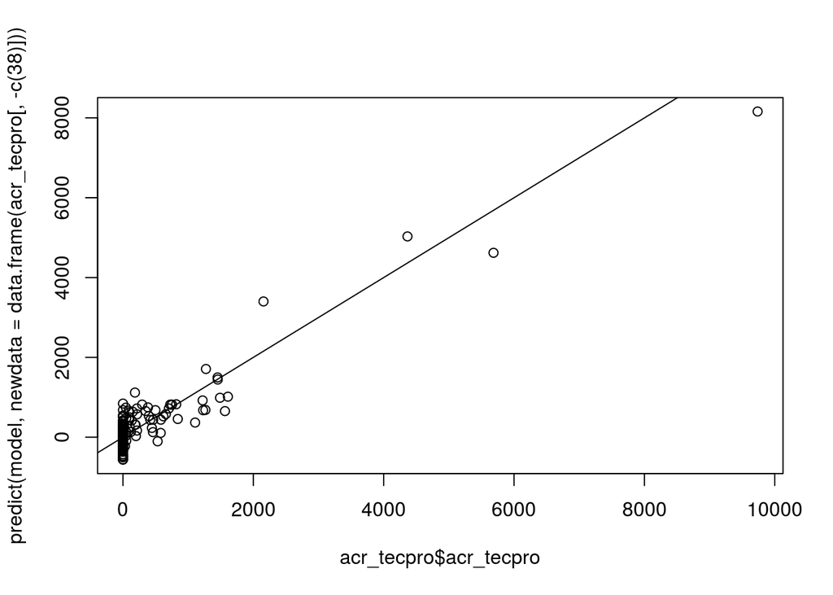

```r
plot(acr_tecpro$acr_tecpro, predict(model, newdata = data.frame(acr_tecpro[, -c(38)])))
abline(coef = c(0, 1))
```

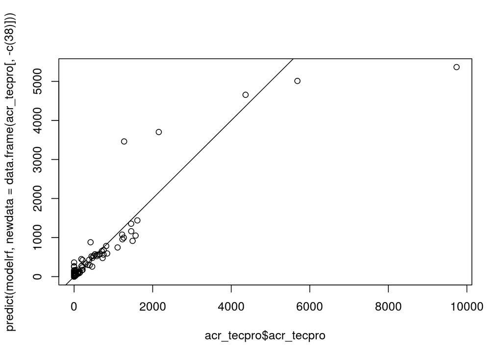

```r
library(caret)
modelrf <- train(acr_tecpro ~ ., data = acr_tecpro, method = "rf")
plot(acr_tecpro$acr_tecpro, predict(modelrf, newdata = data.frame(acr_tecpro[, -c(38)])))
abline(coef = c(0, 1))
```